# How the world uses AI — a guide to the data

Diversity in a Globalized World

Published

September 9, 2026

# What this data is about

Most research on AI and work asks a question it cannot really answer: *which jobs could a machine do?* People build lists of tasks, judge how automatable each one looks, and add them up. It is a reasonable exercise, but it is a prediction about the future, not a record of anything that happened.

This data is different. It is a record of **what people actually did**.

Anthropic, the company that makes the AI assistant Claude, took millions of real conversations, stripped out anything identifying, and classified each one: what kind of work was it, what occupation does that work belong to, was the person studying or working or doing something personal. Then they published the totals, country by country.

So instead of *“jobs like this could be automated”*, you get *“in Tunisia, half of what people ask Claude for is coursework.”*

**This folder contains that data for 121 countries, ready to map.**

# The two files

| File | Use it for | What one row is |
| --- | --- | --- |
| `countries.rds` | **Maps** | One country |
| `occupations.rds` | Comparing what countries use AI *for* | One country, one occupation group |

```r
library(sf)
library(ggplot2)

countries   <- readRDS("preprocessed_data/countries.rds")
occupations <- readRDS("preprocessed_data/occupations.rds")
```

# `countries.rds` — for maps

One row per country, with the shape of the country attached.

```r
countries |> st_drop_geometry() |> filter(iso3 %in% c("MEX","USA","TUN","BRA")) |> head()
```

```
  iso3                  country     continent augmentation_style
1  USA United States of America North America              50.41
2  TUN                  Tunisia        Africa              50.21
3  MEX                   Mexico North America              49.64
4  BRA                   Brazil South America              48.82
  automation_style asked_to_just_do_it asked_to_explain adoption_rate
1            49.59               31.64            16.86         20.16
2            49.79               32.35            17.81          0.27
3            50.36               31.65            13.94          1.32
4            51.18               33.16            11.95          3.33
  used_for_study used_for_personal used_for_work
1           8.94             49.74         41.32
2          51.52             20.54         27.94
3          21.08             33.95         44.97
4          11.52             31.12         57.35
```

| Variable | What it means |
| --- | --- |
| `iso3` | Three-letter country code |
| `country` | Country name |
| `continent` | Continent |
| `adoption_rate` | How much this country uses Claude, relative to its size |
| `used_for_work` | % of conversations that are work |
| `used_for_study` | % that are coursework or studying |
| `used_for_personal` | % that are personal |
| `automation_style` | % where the person handed over a whole task |
| `augmentation_style` | % where the person worked *with* the AI rather than delegating |
| `asked_to_explain` | % where the person wanted the AI to teach them something |
| `asked_to_just_do_it` | % where the person gave an instruction and wanted output |
| `geometry` | The country’s shape — you never touch this directly |

**A map takes one line:**

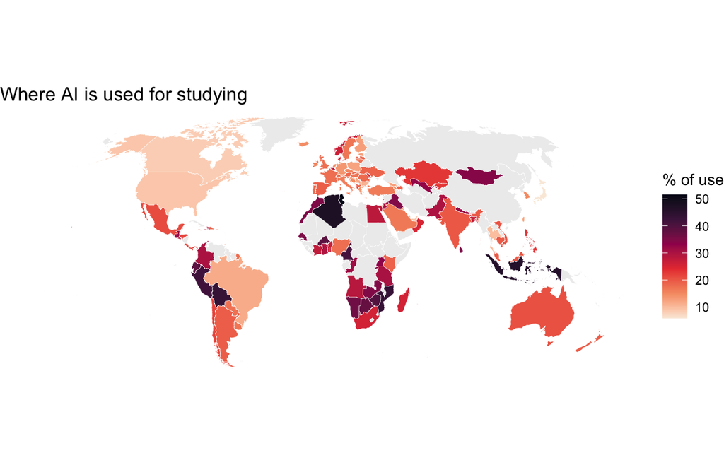

```r
ggplot(countries) +
  geom_sf(aes(fill = used_for_study), color = "white", linewidth = 0.1) +
  scale_fill_viridis_c(option = "rocket", direction = -1, na.value = "grey93",
                       name = "% of use") +
  labs(title = "Where AI is used for studying") +
  coord_sf(crs = "+proj=robin") +
  theme_void()
```

Swap `used_for_study` for any other variable and you get a different map.

There are 241 shapes but only **121 countries have data**. The rest come out grey. That is not a mistake — Claude is not used everywhere, and the grey is itself information.

# `occupations.rds` — what kind of work

For each country, the share of AI use belonging to each of 22 occupation groups.

```r
occupations |> filter(iso3 == "MEX") |> head(5)
```

```
  iso3 country     continent                                     occupation
1  MEX  Mexico North America                      Computer and Mathematical
2  MEX  Mexico North America Arts, Design, Entertainment, Sports, and Media
3  MEX  Mexico North America            Educational Instruction and Library
4  MEX  Mexico North America                              Sales and Related
5  MEX  Mexico North America              Office and Administrative Support
    pct
1 24.90
2 13.18
3 11.58
4  8.67
5  8.35
```

| Variable | What it means |
| --- | --- |
| `iso3`, `country`, `continent` | Same as above |
| `occupation` | One of 22 occupation groups |
| `pct` | % of that country’s AI use falling in this group |

Each country’s percentages add to roughly 100.

# The thing worth noticing first

The **occupational** mix barely changes from country to country. Computing is around a quarter of use almost everywhere; teaching around a seventh. Wherever you look, people use AI for similar *kinds* of work.

But the **purpose** changes enormously.

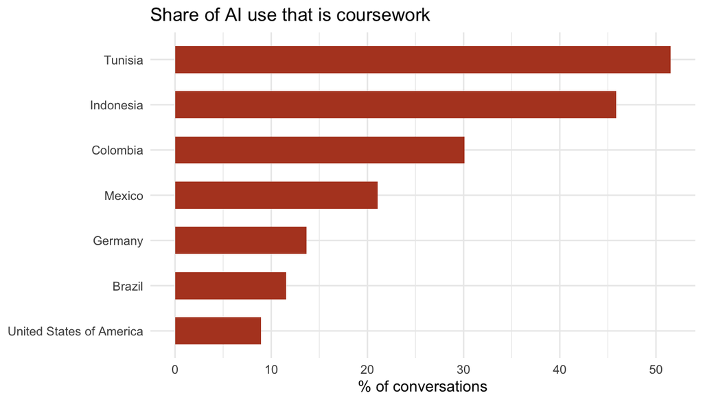

```r
countries |>
  st_drop_geometry() |>
  filter(iso3 %in% c("TUN","IDN","COL","MEX","BRA","DEU","USA")) |>
  ggplot(aes(x = reorder(country, used_for_study), y = used_for_study)) +
  geom_col(fill = "#b44527", width = 0.6) +
  coord_flip() +
  labs(title = "Share of AI use that is coursework",
       x = NULL, y = "% of conversations") +
  theme_minimal()
```

In Tunisia over half of all use is studying. In the United States it is under one in ten, and personal use is nearly half. Mexico sits at about 21%.

Same tool, available on the same terms everywhere, absorbed into completely different parts of life. That is the most interesting thing in this data, and it is a question about societies rather than about technology.

# The big limitation — read this before you conclude anything

This measures **the people who use Claude**, not the people who live in a country.

Look at `adoption_rate`: the United States is around 20, Tunisia around 0.3. So “half of Tunisian use is coursework” means half of a *small* group — almost certainly younger, more urban, better connected and more educated than Tunisians in general.

That does not make the number wrong. It makes it a statement about a particular group of people, and you have to say so. Compare that with the China Shock data, where the denominator is every worker in a place.

Whenever you write a sentence beginning “in country X, people…”, stop and ask whether you mean *people* or *Claude users*. Almost always you mean the second.

# Other things worth knowing

**`automation_style` and `augmentation_style` add to 100.** They split every conversation into two kinds: handing over a whole task, or working alongside the AI. Mapping either one shows where AI is a delegate and where it is a collaborator.

**`adoption_rate` is extremely lopsided.** A few countries are very high and most are near zero. On a plain map almost everything looks the same — try `trans = "sqrt"` inside `scale_fill_viridis_c()`.

**The data covers May 2026**, one month. It is a snapshot, not a trend.

# Questions you could ask

- Which countries use AI mostly for study, and what do they have in common?
- Is `used_for_study` related to how rich a country is, or how young it is? You would need to bring in outside data to check.
- Does `automation_style` differ between richer and poorer countries — do some places delegate to AI while others collaborate with it?
- Do countries with high `adoption_rate` use AI differently from countries just starting out?
- Take one continent. Are neighbouring countries similar, or not at all?
- Where does Mexico sit, and which countries is it most like?

# Where the data comes from

The Anthropic Economic Index, release of 26 June 2026, published under a CC-BY licence at https://huggingface.co/datasets/Anthropic/EconomicIndex.

Country outlines come from Natural Earth. We took the country-level tables from the June 2026 release, kept the May 2026 month, renamed the variables into plain English and attached the map shapes.